# Spam filter

Mine Çetinkaya-Rundel

2020-05-20

```r
library(tidyverse)
library(broom)
library(openintro) # install_github("openintrostat/openintro-r-package")
```

# Spam filters

We will examine a data set of emails where we are interested in identifying spam messages.

- Data from 3921 emails and 21 variables on them.
- The outcome is whether the email is spam or not.
- Explanatory variables are number of characters, whether the word inherit was in the email, number of times the word inherit shows up in the email, etc.

```
Question: Would you expect longer or shorter emails to be spam?
```

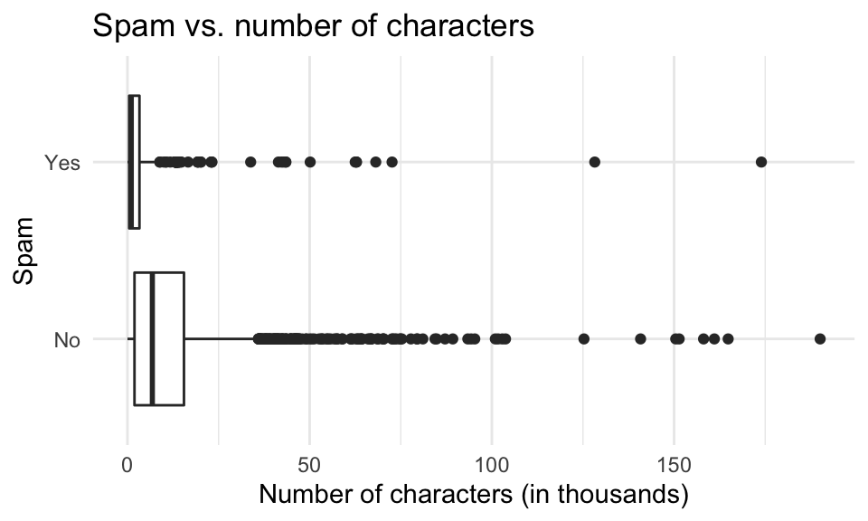

```
Question:
Would you expect emails that have subjects starting with "Re:", "RE:", "re:", or "rE:" to be more likely to be spam or not?
```

```r
email %>%
  mutate(spam = if_else(spam == 1, "Yes", "No")) %>%
  ggplot(aes(y = num_char, x = spam)) +
  geom_boxplot() +
  theme_minimal() +
  labs(
    y = "Number of characters (in thousands)",
    x = "Spam",
    title = "Spam vs. number of characters"
    ) +
  coord_flip()
```

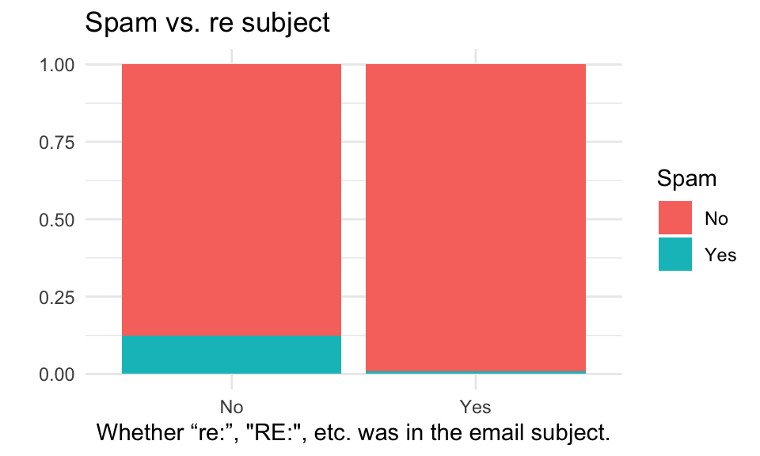

```r
email %>%
  mutate(
    re_subj = if_else(re_subj == 1, "Yes", "No"),
    spam = if_else(spam == 1, "Yes", "No")
    ) %>%
  ggplot(aes(x = re_subj, fill = spam)) +
  geom_bar(position = "fill") +
  theme_minimal() +
  labs(
    x = 'Whether “re:”, "RE:", etc. was in the email subject.',
    fill = "Spam",
    y = "",
    title = "Spam vs. re subject"
    )
```

## Modeling spam

- It seems clear that both number of characters and whether the message has “re:” in the subject are somewhat related to whether the email is spam. How do we come up with a model that will let us explore this relationship?
- For simplicity, we’ll focus on the number of character (`num_char`) as the explanatory variable, but the model we describe can be expanded to take multiple explanatory variables as well.

Even if we set not spam to 0 and spam to 1, this isn’t something we can reasonably fit a linear model to - we need something more.

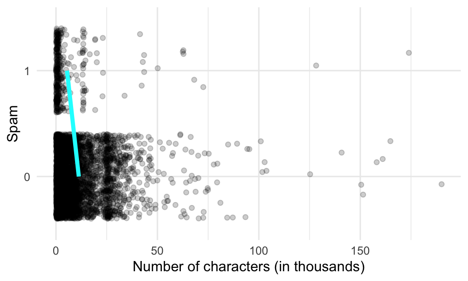

```r
means <- email %>%
  group_by(spam) %>%
  summarise(mean_num_char = mean(num_char)) %>%
  mutate(group = 1)

ggplot(email, aes(x = num_char, y = spam)) +
  geom_jitter(alpha = 0.2) +
  geom_line(data = means, aes(x = mean_num_char, y = spam, group = group),
            color = "cyan", size = 1.5) +
  theme_minimal() +
  labs(x = "Number of characters (in thousands)", y = "Spam")
```

## Framing the problem

We can treat each outcome (spam and not) as successes and failures arising from separate Bernoulli trials. A Bernoulli trial is a random experiment with exactly two possible outcomes, “success” and “failure”, in which the probability of success is the same every time the experiment is conducted

- Each Bernoulli trial can have a separate probability of success

$$y_i ∼ Bern(p)$$

- We can then use the predictor variables to model that probability of success, $p_i$
- We can’t just use a linear model for $p_i$ (since $p_i$ must be between 0 and 1) but we can transform the linear model to have the appropriate range

# Generalized linear models

It turns out that this is a very general way of addressing many problem in regression, and the resulting models are called generalized linear models (GLMs). Logistic regression is just one example.

All generalized linear models have the following three characteristics

1. A probability distribution describing a generative model for the outcome variable
2. A linear model:
   $$\eta = \beta_0 + \beta_1 X_1 + \cdots + \beta_k X_k$$
3. A link function that relates the linear model to the parameter of the outcome distribution

## Logistic regression

Logistic regression is a GLM used to model a binary categorical outcome using numerical and categorical predictors.

To finish specifying the Logistic model we just need to define a reasonable link function that connects $\eta_i$ to $p_i$. There are a variety of options but the most commonly used is the **logit function**.

$$logit(p) = \log\left(\frac{p}{1-p}\right),\text{ for $0\le p \le 1$}$$

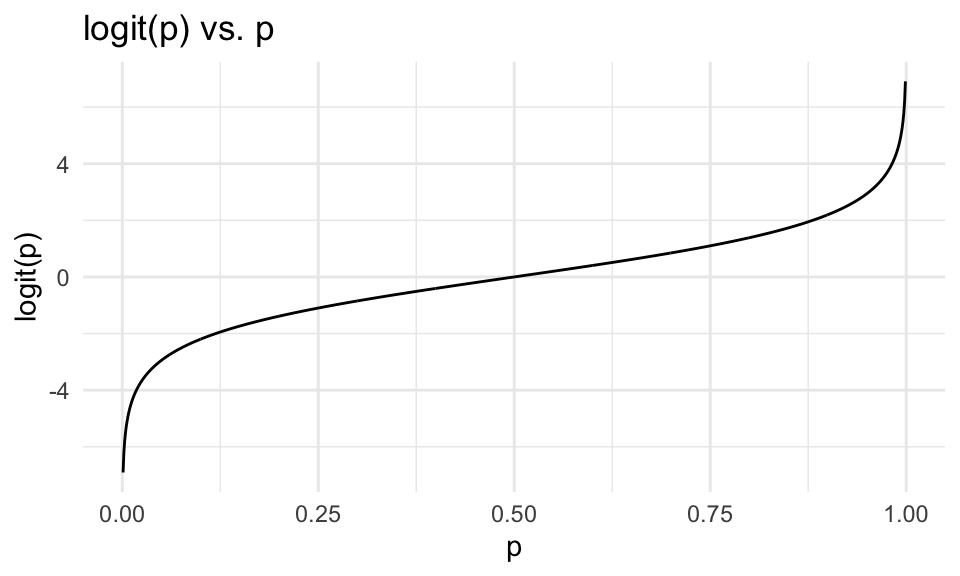

```r
d <- tibble(p = seq(0.001, 0.999, length.out = 1000)) %>%
  mutate(logit_p = log(p/(1-p)))

ggplot(d, aes(x = p, y = logit_p)) +
  geom_line() +
  xlim(0,1) +
  ylab("logit(p)") +
  theme_minimal() +
  labs(title = "logit(p) vs. p")
```

## Properties of the logit

- The logit function takes a value between 0 and 1 and maps it to a value between $-\infty$ and $\infty$.
- Inverse logit (logistic) function:
  $$g^{-1}(x) = \frac{\exp(x)}{1+\exp(x)} = \frac{1}{1+\exp(-x)}$$
- The inverse logit function takes a value between $-\infty$ and $\infty$ and maps it to a value between 0 and 1.
- This formulation is also useful for interpreting the model, since the logit can be interpreted as the log odds of a success - more on this later.

## The logistic regression model

- The three GLM criteria give us:
  - $y_i \sim \text{Bern}(p_i)$
  - $\eta_i = \beta_0+\beta_1 x_{1,i} + \cdots + \beta_n x_{n,i}$
  - $\text{logit}(p_i) = \eta_i$
- From which we get,

$$p_i = \frac{\exp(\beta_0+\beta_1 x_{1,i} + \cdots + \beta_k x_{k,i})}{1+\exp(\beta_0+\beta_1 x_{1,i} + \cdots + \beta_k x_{k,i})}$$

## Modeling spam

In R we fit a GLM in the same way as a linear model except we use `glm()` instead of `lm()`. We specify the type of GLM to fit using the `family` argument.

```r
spam_model <- glm(spam ~ num_char, data = email, family = "binomial")
tidy(spam_model)
```

```
## # A tibble: 2 x 5
##   term        estimate std.error statistic   p.value
##   <chr>          <dbl>     <dbl>     <dbl>     <dbl>
## 1 (Intercept)  -1.80     0.0716     -25.1  2.04e-139
## 2 num_char     -0.0621   0.00801     -7.75 9.50e- 15
```

## Spam model

```r
tidy(spam_model)
```

```
## # A tibble: 2 x 5
##   term        estimate std.error statistic   p.value
##   <chr>          <dbl>     <dbl>     <dbl>     <dbl>
## 1 (Intercept)  -1.80     0.0716     -25.1  2.04e-139
## 2 num_char     -0.0621   0.00801     -7.75 9.50e- 15
```

Model:
$$\log\left(\frac{p}{1-p}\right) = -1.80-0.0621\times \text{num_char}$$

## P(spam) for an email with 2000 characters

$$\log\left(\frac{p}{1-p}\right) = -1.80-0.0621\times 2$$

$$\frac{p}{1-p} = \exp(-1.9242) = 0.15 \rightarrow p = 0.15 \times (1 - p)$$

$$p = 0.15 - 0.15p \rightarrow 1.15p = 0.15$$

$$p = 0.15 / 1.15 = 0.13$$

```
Question: What is the probability that an email with 15000 characters is spam? What about an email with 40000 characters?
```

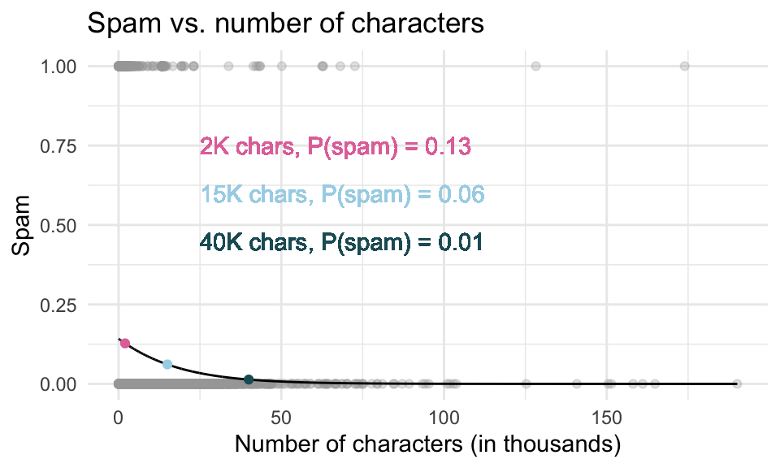

```
Question: Would you prefer an email with 2000 characters to be labeled as spam or not? How about 40,000 characters?
```

```r
newdata <- tibble(
  num_char = c(2, 15, 40),
  color    = c("#E274A8", "#A7D5E8", "#1E5C65")
  )
newdata <- newdata %>%
  mutate(
    y_hat = predict(spam_model, newdata),
    p_hat = exp(y_hat) / (1 + exp(y_hat))
  )

spam_model_aug <- augment(spam_model) %>%
  mutate(prob = exp(.fitted) / (1 + exp(.fitted)))
ggplot(spam_model_aug, aes(x = num_char)) +
  geom_point(aes(y = as.numeric(spam)-1), alpha = 0.3, color = "darkgray") +
  geom_line(aes(y = prob)) +
  geom_point(data = newdata, aes(x = num_char, y = p_hat),
             color = newdata$color) +
  geom_text(x = 25, y = 0.75,
            label = paste0(newdata$num_char[1], "K chars, P(spam) = ", round(newdata$p_hat[1], 2)),
            color = newdata$color[1], hjust = "left") +
  geom_text(x = 25, y = 0.60,
            label = paste0(newdata$num_char[2], "K chars, P(spam) = ", round(newdata$p_hat[2], 2)),
            color = newdata$color[2], hjust = "left") +
  geom_text(x = 25, y = 0.45,
            label = paste0(newdata$num_char[3], "K chars, P(spam) = ", round(newdata$p_hat[3], 2)),
            color = newdata$color[3], hjust = "left") +
  theme_minimal() +
  labs(
    x = "Number of characters (in thousands)",
    y = "Spam",
    title = "Spam vs. number of characters"
  )
```

[figure not shown]

```r
ggplot(spam_model_aug, aes(x = num_char)) +
  geom_point(aes(y = as.numeric(spam)-1), alpha = 0.3, color = "darkgray") +
  geom_line(aes(y = prob)) +
  theme_minimal() +
  labs(
    x = "Number of characters (in thousands)",
    y = "Spam",
    title = "Spam vs. number of characters"
  ) +
  geom_vline(xintercept = newdata$num_char[1],
             color = newdata$color[1], size = 1, alpha = 0.5) +
  geom_vline(xintercept = newdata$num_char[3],
             color = newdata$color[3], size = 1, alpha = 0.5) +
  geom_text(x = 55, y = 0.75,
            label = paste0(newdata$num_char[1], "K chars, P(spam) = ", round(newdata$y_hat[1], 2)),
            color = newdata$color[1], hjust = "left") +
  geom_text(x = 55, y = 0.65,
            label = paste0(newdata$num_char[3], "K chars, P(spam) = ", round(newdata$y_hat[3], 2)),
            color = newdata$color[3], hjust = "left")
```

# Sensitivity and specificity

|  | Email is spam | Email is not spam |
| --- | --- | --- |
| Email labelled spam | True positive | False positive (Type 1 error) |
| Email labelled not spam | False negative (Type 2 error) | True negative |

- False negative rate = P(Labelled not spam | Email spam) = FN / (TP + FN)
- False positive rate = P(Labelled spam | Email not spam) = FP / (FP + TN)
- Sensitivity = P(Labelled spam | Email spam) = TP / (TP + FN)
  - Sensitivity = 1 − False negative rate
- Specificity = P(Labelled not spam | Email not spam) = TN / (FP + TN)
  - Specificity = 1 − False positive rate

```
Question: If you were designing a spam filter, would you want sensitivity and specificity to be high or low? What are the tradeoffs associated with each decision?
```

## Using logistic regression to build a spam filter

We have a set of emails we are interested in identifying spam messages. Using logistic regression we can predict the probability an incoming message is spam. Using model selection, we can pick a model with the highest predictive power.

But when designing a spam filter this is only half of the battle, we would also need to design a decision rule about which emails get flagged as spam (e.g. what probability should we use as out cutoff?)

While not the only possible solution, we can consider a simple approach where we choose a single threshold probability and any email that exceeds that probability is flagged as spam.